# Writing a great story for data science projects

# Random Forest Analysis of Customer Order Data

[output not shown]

## Introduction

This document presents a Random Forest analysis of customer order data, focusing on predicting fulfillment rates based on various features.

## Setup and Data Preparation

First, we’ll load the necessary libraries and create our dataset based on the bar graph data.

```r
library(tidyverse)
library(randomForest)
library(caret)

# Create the dataset based on the bar graph data
customer_data <- tibble(
  Customer = c("Smoothie Island", "Philly Bite", "PlatePioneers", "Berl Company", "DineLink Intl"),
  TotalOrders = c(1701, 1556, 1396, 906, 589),
  ClosedShort = c(455, 267, 143, 5, 42),
  Fulfilled = c(1246, 1289, 1253, 901, 547)
)

# Feature engineering
customer_data <- customer_data %>%
  mutate(
    FulfillmentRate = Fulfilled / TotalOrders,
    OrderSize = case_when(
      TotalOrders >= 1500 ~ "Large",
      TotalOrders >= 1000 ~ "Medium",
      TRUE ~ "Small"
    )
  )

# Convert categorical variables to factors
customer_data$Customer <- as.factor(customer_data$Customer)
customer_data$OrderSize <- as.factor(customer_data$OrderSize)

# Display the prepared data
knitr::kable(customer_data)
```

| Customer | TotalOrders | ClosedShort | Fulfilled | FulfillmentRate | OrderSize |
| --- | --- | --- | --- | --- | --- |
| Smoothie Island | 1701 | 455 | 1246 | 0.7325103 | Large |
| Philly Bite | 1556 | 267 | 1289 | 0.8284062 | Large |
| PlatePioneers | 1396 | 143 | 1253 | 0.8975645 | Medium |
| Berl Company | 906 | 5 | 901 | 0.9944812 | Small |
| DineLink Intl | 589 | 42 | 547 | 0.9286927 | Small |

## Data Splitting

We’ll split our data into training and testing sets. Note that due to the small sample size, this split may not be very meaningful, but we include it for demonstration purposes.

```r
set.seed(123)  # for reproducibility
train_index <- createDataPartition(customer_data$FulfillmentRate, p = 0.8, list = FALSE)
train_data <- customer_data[train_index, ]
test_data <- customer_data[-train_index, ]
```

## Random Forest Model

Now, we’ll train our Random Forest model using the training data.

```r
rf_model <- randomForest(
  FulfillmentRate ~ Customer + TotalOrders + OrderSize,
  data = train_data,
  ntree = 500,
  mtry = 2,
  importance = TRUE
)

# Print summary of the model
print(rf_model)
```

```
Call:
 randomForest(formula = FulfillmentRate ~ Customer + TotalOrders +      OrderSize, data = train_data, ntree = 500, mtry = 2, importance = TRUE)
               Type of random forest: regression
                     Number of trees: 500
No. of variables tried at each split: 2

          Mean of squared residuals: 0.006713408
                    % Var explained: 16.36
```

## Model Evaluation

Let’s evaluate our model by making predictions on the test set and calculating performance metrics.

```r
# Make predictions on the test set
predictions <- predict(rf_model, test_data)

# Evaluate the model
mse <- mean((predictions - test_data$FulfillmentRate)^2)
rsquared <- 1 - (sum((test_data$FulfillmentRate - predictions)^2) /
                 sum((test_data$FulfillmentRate - mean(test_data$FulfillmentRate))^2))

cat("Mean Squared Error:", mse, "\n")
```

[output not shown]

```
Mean Squared Error: NaN
```

```r
cat("R-squared:", rsquared, "\n")
```

```
R-squared: NaN
```

## Feature Importance

We can analyze which features are most important in our model’s predictions.

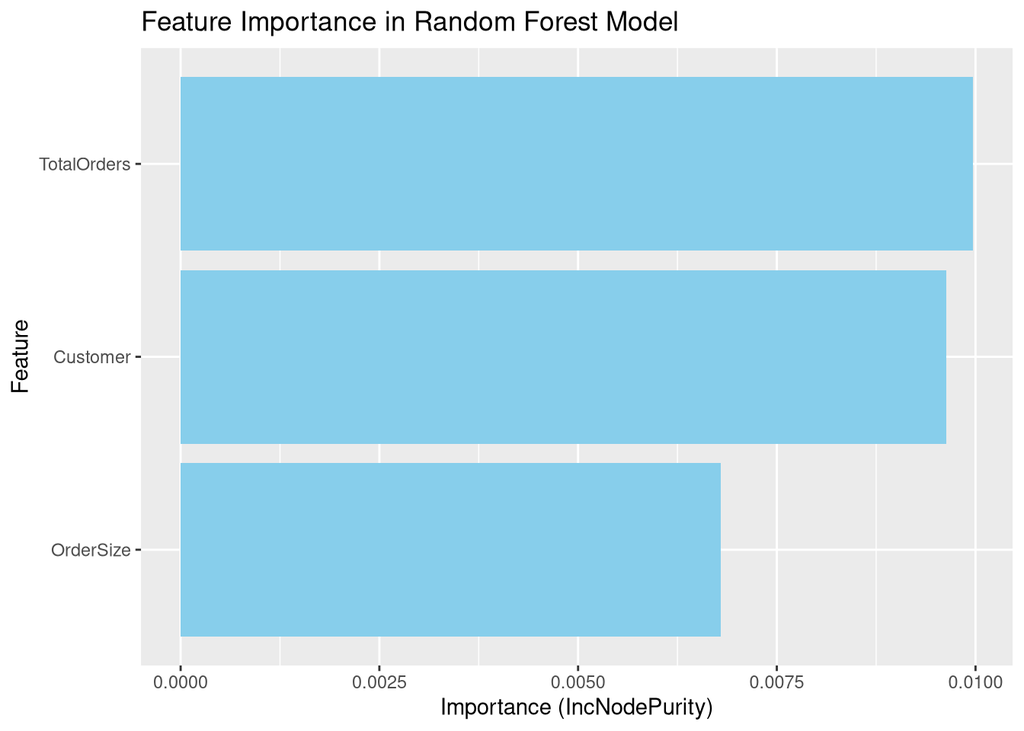

Feature Importance in Random Forest Model

```r
importance_df <- importance(rf_model) %>%
  as.data.frame() %>%
  rownames_to_column("Feature") %>%
  arrange(desc(IncNodePurity))

ggplot(importance_df, aes(x = reorder(Feature, IncNodePurity), y = IncNodePurity)) +
  geom_bar(stat = "identity", fill = "skyblue") +
  coord_flip() +
  labs(title = "Feature Importance in Random Forest Model",
       x = "Feature",
       y = "Importance (IncNodePurity)")
```

## Actual vs Predicted Fulfillment Rates

Finally, let’s visualize how our model’s predictions compare to the actual fulfillment rates.

[figure not shown]

Actual vs Predicted Fulfillment Rates

```r
ggplot(data.frame(Actual = test_data$FulfillmentRate, Predicted = predictions),
       aes(x = Actual, y = Predicted)) +
  geom_point() +
  geom_abline(intercept = 0, slope = 1, color = "red", linetype = "dashed") +
  labs(title = "Actual vs Predicted Fulfillment Rates",
       x = "Actual Fulfillment Rate",
       y = "Predicted Fulfillment Rate")
```

## References

Breiman, Leo. 2001. “Random Forests.” *Machine Learning* 45 (1): 5–32.

Fernández-Delgado, Manuel, Eva Cernadas, Senén Barro, and Dinani Amorim. 2014. “Do We Need Hundreds of Classifiers to Solve Real World Classification Problems?” *The Journal of Machine Learning Research* 15 (1): 3133–81.

Hastie, Trevor, Robert Tibshirani, and Jerome Friedman. 2009. *The Elements of Statistical Learning: Data Mining, Inference, and Prediction*. Springer Science & Business Media.

Louppe, Gilles. 2014. “Understanding Random Forests: From Theory to Practice.” *arXiv Preprint arXiv:1407. 7502*.

Lundberg, Scott M, and Su-In Lee. 2017. “A Unified Approach to Interpreting Model Predictions.” *Advances in Neural Information Processing Systems* 30.

Strobl, Carolin, Anne-Laure Boulesteix, Achim Zeileis, and Torsten Hothorn. 2007. “Bias in Random Forest Variable Importance Measures: Illustrations, Sources and a Solution.” *BMC Bioinformatics* 8 (1): 1–21.

|  | Total Orders | Closed Short | Fulfilled |
| --- | --- | --- | --- |
|  | (n=7585) | (n=733) | (n=6852) |
| Top Customers |  |  |  |
| Smoothie Island | 1701 (22.43%) | 455 (62.07%) | 1246 (18.18%) |
| Philly Bite | 1556 (20.51%) | 267 (36.43%) | 1289 (18.81%) |
| PlatePioneers | 1396 (18.40%) | 143 (19.51%) | 1253 (18.29%) |
| Berl Company | 906 (11.94%) | 5 (0.68%) | 901 (13.15%) |
| DineLink Intl | 589 (7.77%) | 42 (5.73%) | 547 (7.98%) |
| Top Products |  |  |  |
| DC-01 | 1135 (14.96%) | 345 (47.07%) | 790 (11.53%) |
| TSC-PQB-01 | 1087 (14.33%) | 389 (53.07%) | 698 (10.19%) |
| TSC-PW14X16-01 | 848 (11.18%) | 283 (38.61%) | 565 (8.25%) |
| CMI-PCK-01 | 802 (10.57%) | 288 (39.29%) | 514 (7.50%) |
| PC-05-B1 | 745 (9.82%) | 220 (30.01%) | 525 (7.66%) |
| Top Distributors |  |  |  |
| Ed Don & Company - Miramar | 210 (2.77%) | 0 (0.00%) | 210 (3.06%) |
| PFG- Gainesville | 197 (2.60%) | 0 (0.00%) | 197 (2.88%) |
| Ed Don & Company - Woodridge | 186 (2.45%) | 0 (0.00%) | 186 (2.71%) |
| Ed Don & Company - Mira Loma | 180 (2.37%) | 0 (0.00%) | 180 (2.63%) |
| .Ed Don - Miramar | 162 (2.14%) | 0 (0.00%) | 162 (2.36%) |
| Top Substrates | Paper | Plastic | Bagasse |
| Revenue($103,826,286) | $54,838,585 (52.82%) | $40,336,669 (38.85%) | $4,350,337 (4.19%) |
| Quantity Ordered | Min | Mean | Max |
| Total Ordered(1,971,237) | 1 | 61.47 | 23,160 |
| Unit Price | Min | Mean | Max |
| Key Stats | $0.16 | $62.60 | $864.00 |
| Total Price | Min | Mean | Max |
| Key Stats | $4.92 | $3,430.74 | $143,084.74 |